# シリアル3次元画像をジグザグ持続ホモロジーで読む

共焦点顕微鏡の z スタック(skimage `cells3d`)で試す

公開

2026年11月13日

## 1. シリアル3次元画像とは

**同じ物体を少しずつ位置をずらしながら撮った 2D 画像の束**のことです。1枚1枚を「スライス」、束を「スタック」と呼びます。

| 撮り方 | 何をずらすか | 例 |
| --- | --- | --- |
| 共焦点顕微鏡の **z スタック** | 焦点面の深さ | 細胞・組織の蛍光像 |
| **連続切片**(serial section)電子顕微鏡 | 物理的に薄く切った切片の順番 | 脳の神経回路の再構成 |
| CT / MRI | 体軸方向の位置 | 医用画像 |
| (変種)**3D の時系列** | 時刻 | 生きた細胞の分裂の追跡 |

並べると3次元のボリュームになりますが、データとしてはあくまで「スライスの列」です。スライスどうしの位置がずれていたり、深いほど暗くなったりします。

このレポートで使うのは scikit-image に付属の `cells3d` です。培養細胞を共焦点顕微鏡で撮った **60 枚の z スタック**で、チャンネルは2つあります(0 = 細胞膜、1 = 核)。

**コード**

```
形: (60, 2, 256, 256)  ボクセル間隔(公式): z 0.29 µm, xy 0.26 µm
```

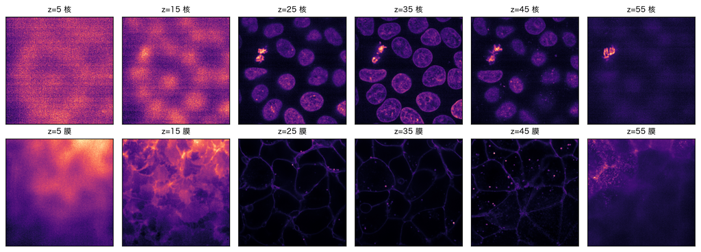

```python
V = data.cells3d()                      # (z, ch, y, x) = (60, 2, 256, 256)
print("形:", V.shape, " ボクセル間隔(公式): z 0.29 µm, xy 0.26 µm")
zs = [5, 15, 25, 35, 45, 55]
fig, axs = plt.subplots(2, 6, figsize=(12, 4.4))
for j, z in enumerate(zs):
    for c, name in [(1, "核"), (0, "膜")]:
        ax = axs[0 if c == 1 else 1, j]
        ax.imshow(V[z, c], cmap="magma"); ax.set_xticks([]); ax.set_yticks([])
        ax.set_title(f"z={z} {name}", fontsize=9)
plt.tight_layout(); plt.show()
```

同じ視野で深さだけが変わっています。核(上段)は浅いところには写らず、中ほどの深さで大きく写り、また消えていきます。

## 2. 何をしたいか:スライスをまたいで「同じもの」を数える

1枚ごとに核の塊を数えるのは簡単です(連結成分ラベリング)。問題は **次のスライスのどの塊が前のどれと同じか** です。塊はスライスを進むうちに

- 現れる/消える
- 1つが2つに分かれる/2つが1つにくっつく
- 輪っか(穴)ができる/ふさがる

と変化します。これを手で対応付けると、規則をどう書くかで答えが変わってしまいます。

### ジグザグ持続ホモロジー

隣り合うスライス $S_i, S_{i+1}$ は包含関係にない(どちらかが他方に含まれるわけではない)ので、普通の持続ホモロジー(大きくなっていく列 $X_0\subset X_1\subset\cdots$)は使えません。そこで **和集合をはさんで、矢印の向きを交互に** します。

$$S_0 \hookrightarrow S_0\cup S_1 \hookleftarrow S_1 \hookrightarrow S_1\cup S_2 \hookleftarrow S_2 \hookrightarrow \cdots$$

和集合 $S_i\cup S_{i+1}$ は「2枚を重ねた画像」です。$S_i$ の塊と $S_{i+1}$ の塊が重ねた画像の中でつながっていれば、**同じものが続いている**とみなされます。

このジグザグ列にも普通の持続ホモロジーと同じく**バーコード**が一意に定まります(Carlsson–de Silva 2010)。各バーは

- **H0 のバー**:ある塊が「何枚目から何枚目まで」続いたか
- **H1 のバー**:ある穴(輪っかに囲まれた領域)が「何枚目から何枚目まで」続いたか

を表します。バーの始まりと終わりは「現れた・分かれた・くっついた・消えた」のどれかです。

**ノート実装の中身(クリックで開く)**

## 3. 答えが分かっている人工データで読み方を練習

まず作り物で確かめます。30 枚のスライスに3つの物体を置きました。

- **A:Y 字の管** — 下から1本で上がってきて、15 枚目で2本に分かれる
- **B:中空の筒** — 5〜20 枚目だけにある。断面は輪っか
- **C:Λ 字** — 2本で上がってきて、18 枚目で1本にくっつく

**コード**

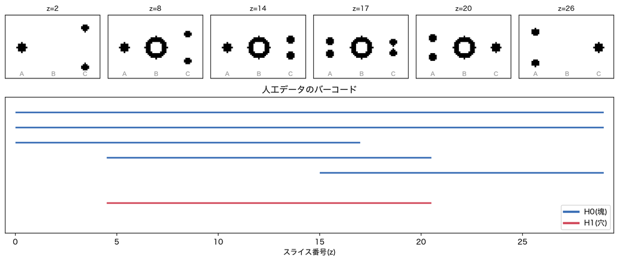

```python
n, H, W = 30, 40, 60
yy, xx = np.mgrid[:H, :W]
toy = np.zeros((n, H, W), bool)
for z in range(n):
    # A: Y字
    if z < 15:
        toy[z] |= (xx - 10) ** 2 + (yy - 20) ** 2 <= 9
    else:
        dx = (z - 15) * 0.6 + 3
        toy[z] |= (xx - 10) ** 2 + (yy - 20 + dx) ** 2 <= 6
        toy[z] |= (xx - 10) ** 2 + (yy - 20 - dx) ** 2 <= 6
    # B: 筒
    if 5 <= z <= 20:
        r2 = (xx - 30) ** 2 + (yy - 20) ** 2
        toy[z] |= (r2 <= 49) & (r2 >= 16)
    # C: Λ字
    if z < 18:
        dx = (18 - z) * 0.6 + 2.6
        toy[z] |= (xx - 50) ** 2 + (yy - 20 + dx) ** 2 <= 5
        toy[z] |= (xx - 50) ** 2 + (yy - 20 - dx) ** 2 <= 5
    else:
        toy[z] |= (xx - 50) ** 2 + (yy - 20) ** 2 <= 9
res_toy, T = zigzag(toy)

fig = plt.figure(figsize=(12, 5.2))
gs = fig.add_gridspec(2, 6, height_ratios=[1, 1.5])
for j, z in enumerate([2, 8, 14, 17, 20, 26]):
    ax = fig.add_subplot(gs[0, j]); ax.imshow(toy[z], cmap="gray_r")
    ax.set_title(f"z={z}", fontsize=9); ax.set_xticks([]); ax.set_yticks([])
    for x, lab in [(10, "A"), (30, "B"), (50, "C")]:
        ax.text(x, 38, lab, ha="center", fontsize=8, color="#888")
ax = fig.add_subplot(gs[1, :]); barcode(ax, res_toy, n, title="人工データのバーコード")
plt.tight_layout(); plt.show()
```

3次元で見るとこうなります(ドラッグで回転できます。上に行くほどスライス番号が大きい)。

**コード**

```python
tz, ty, tx = np.mgrid[:n, :H, :W]
fig = go.Figure(go.Isosurface(
    x=tx.ravel(), y=ty.ravel(), z=tz.ravel(), value=toy.astype(np.float32).ravel(),
    isomin=0.5, isomax=1, surface_count=1, colorscale=[[0, "#3b6fb6"], [1, "#3b6fb6"]], showscale=False,
    caps=dict(x_show=False, y_show=False, z_show=False)))
for x, lab in [(10, "A:Y字"), (30, "B:筒"), (50, "C:Λ字")]:
    fig.add_trace(go.Scatter3d(x=[x], y=[-6], z=[0], mode="text", text=[lab], showlegend=False))
fig.update_layout(height=480, margin=dict(l=0, r=0, t=0, b=0),
                  scene=dict(aspectmode="data", xaxis_title="x", yaxis_title="y", zaxis_title="スライス番号",
                             camera=dict(eye=dict(x=0.2, y=-1.9, z=0.5))))
fig.show()
```

[interactive chart not shown]

| 次元 | 始まり | 終わり |
| --- | --- | --- |
| H0 | 0 | 17 |
| H0 | 0 | 29 |
| H0 | 0 | 29 |
| H0 | 4.5 | 20.5 |
| H0 | 15 | 29 |
| H1 | 4.5 | 20.5 |

読み方:

- **0〜29 の長い H0 が2本**:A の幹と、C のうち合流後も続く側。
- **15〜29 の H0**:A が分かれて**新しく生まれた**枝。分岐は「バーの誕生」として出ます。
- **0〜17 の H0**:C の片方の脚。17 枚目と 18 枚目を重ねた段階でもう片方とつながり、**片方が死にます**。最後に単独で存在したのは 17 枚目なので、17 で終わります。
- **4.5〜20.5 の H0 と H1 が1本ずつ**:B の筒の「塊」と「穴」。B があるのは 5〜20 枚目ですが、4 枚目と 5 枚目を重ねた段階で既に写っているので、バーは 4.5 から始まります(終わりの 20.5 も同様)。現れる・消えるは .5 に、分かれる・くっつくは整数に出ます。

注意点が1つあります。Y で分かれた2本のうち**どちらが元の幹か**は数学的には決まりません。バーの本数と長さは一意ですが、「どの塊がどのバーか」の割り当ては一意ではないのです。

## 4. 実データ:核チャンネル

### 前処理

- xy を 1/4 に縮小(256→64。計算量のため。1 ピクセル ≈ 1 µm)
- 軽くぼかしてから、**スタック全体で1つの閾値**(大津の方法)で2値化

**コード**

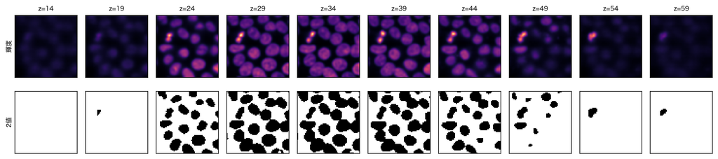

```python
v = transform.downscale_local_mean(V[:, 1].astype(float), (1, 4, 4))
v = filters.gaussian(v, sigma=(0.5, 1, 1))
th = filters.threshold_otsu(v)
S = v > th
nz = len(S)
fig, axs = plt.subplots(2, 10, figsize=(13, 3.2))
for j, z in enumerate(range(14, 60, 5)):
    axs[0, j].imshow(v[z], cmap="magma", vmax=v.max()); axs[1, j].imshow(S[z], cmap="gray_r")
    axs[0, j].set_title(f"z={z}", fontsize=8)
    for a in axs[:, j]: a.set_xticks([]); a.set_yticks([])
axs[0, 0].set_ylabel("輝度", fontsize=8); axs[1, 0].set_ylabel("2値", fontsize=8)
plt.tight_layout(); plt.show()
```

3次元で見るとこうなります(ドラッグで回転できます。z は実寸比)。

**コード**

```python
L3 = measure.label(S, connectivity=3)
vs = transform.downscale_local_mean(v, (2, 2, 2)).astype(np.float32)  # 表示用に間引く
zz_, yy_, xx_ = np.mgrid[:vs.shape[0], :32, :32].astype(np.float32)
fig = go.Figure(go.Isosurface(
    x=xx_.ravel() * 2.08, y=yy_.ravel() * 2.08, z=zz_.ravel() * 0.58, value=vs.ravel(),
    isomin=th, isomax=v.max(), surface_count=1, colorscale="Viridis", showscale=False,
    caps=dict(x_show=False, y_show=False, z_show=False), opacity=0.9))
fig.update_layout(height=520, margin=dict(l=0, r=0, t=0, b=0),
                  scene=dict(aspectmode="data", xaxis_title="x (µm)", yaxis_title="y (µm)", zaxis_title="z (µm)"))
fig.show()
```

[interactive chart not shown]

### ジグザグ持続の計算と検算

**コード**

```python
res, T = zigzag(S)
ok = all(alive(res[0], 2 * i) == measure.label(S[i], connectivity=2).max()
         and alive(res[0], 2 * i) - alive(res[1], 2 * i) == measure.euler_number(S[i], connectivity=2)
         for i in range(nz))
print(f"H0 バー {len(res[0])} 本, H1 バー {len(res[1])} 本")
print("検算: 全スライスで『生きている H0 本数 = 2D の連結成分数』『H0−H1 = オイラー数』:", ok)
```

```
H0 バー 44 本, H1 バー 1 本
検算: 全スライスで『生きている H0 本数 = 2D の連結成分数』『H0−H1 = オイラー数』: True
```

検算の意味:どのスライスの時点でも、その瞬間に生きているバーの本数が、そのスライス単独で数えた塊・穴の数と一致しなければなりません。全 60 枚で一致しました。

**コード**

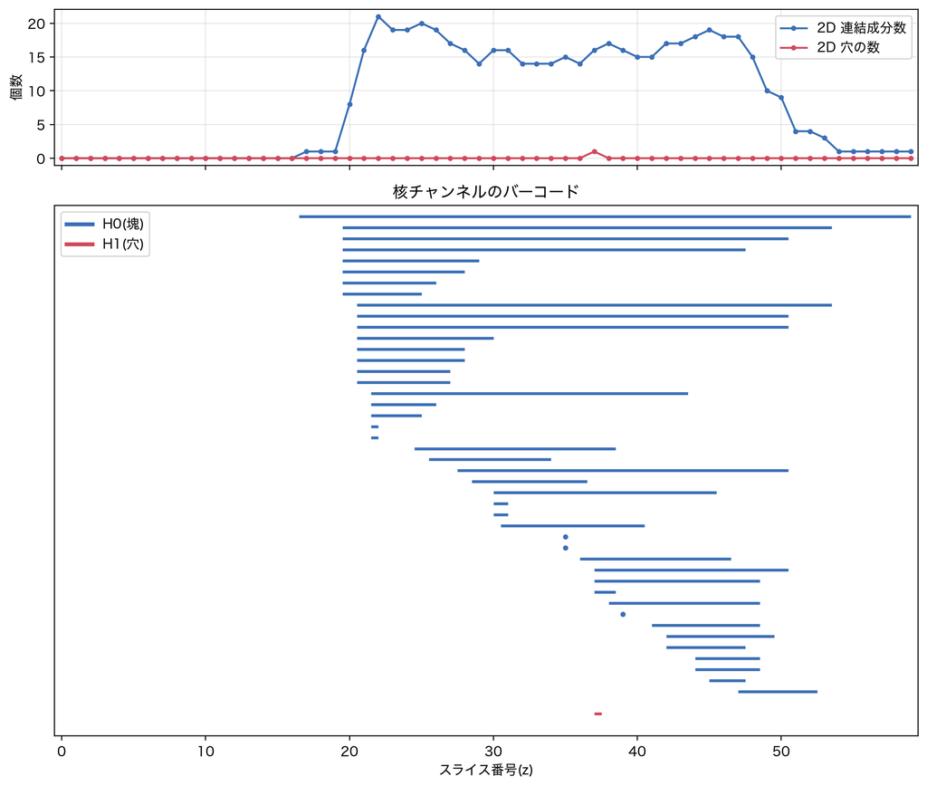

```python
fig, axs = plt.subplots(2, 1, figsize=(10, 8.5), height_ratios=[1, 3.4], sharex=True)
axs[0].plot(range(nz), [measure.label(s, connectivity=2).max() for s in S], "-o", ms=3, color="#3b6fb6", label="2D 連結成分数")
axs[0].plot(range(nz), [alive(res[1], 2 * i) for i in range(nz)], "-o", ms=3, color="#d1495b", label="2D 穴の数")
axs[0].legend(); axs[0].set_ylabel("個数"); axs[0].grid(alpha=.3)
barcode(axs[1], res, nz, title="核チャンネルのバーコード", loc="upper left")
axs[1].tick_params(labelbottom=True)
plt.tight_layout(); plt.show()
```

上の折れ線は「各スライスで数えた塊の数」です。下のバーコードは、その数の増減を**どの塊が生まれ、どの塊が消えたか**に分解したものです。上のグラフの各 z で縦に切ると、そこを通るバーの本数が上の値になります。

### 3D の連結成分と比べる

ボリューム全体を3次元で連結成分ラベリングすると、塊は 12 個です。一方 H0 のバーは 44 本あります。食い違うのは、**3D では1つの塊でも、スライスで見ると何本かの脚が途中で合流している**からです(人工データの Λ と同じ)。

| 3D 成分 | ボクセル数 | z の範囲 | H0 バー | うち 3 枚以上続く | H1 バー |
| --- | --- | --- | --- | --- | --- |
| 2 | 14765 | 20–53 | 9 | 8 | 0 |
| 7 | 12833 | 21–50 | 15 | 13 | 1 |
| 6 | 6760 | 21–53 | 5 | 5 | 0 |
| 3 | 2744 | 20–50 | 1 | 1 | 0 |
| 1 | 2738 | 17–59 | 1 | 1 | 0 |
| 5 | 2035 | 21–50 | 1 | 1 | 0 |
| 4 | 1551 | 20–47 | 1 | 1 | 0 |
| 8 | 820 | 22–43 | 3 | 1 | 0 |
| 10 | 243 | 28–50 | 3 | 1 | 0 |
| 9 | 94 | 25–38 | 3 | 1 | 0 |
| 12 | 16 | 31–40 | 1 | 1 | 0 |
| 11 | 8 | 29–36 | 1 | 1 | 0 |

成分ごとに切り出して同じ計算をした表です。大きな成分(核が何個かくっついて写ったもの)ほど H0 バーが多く、小さな成分はほぼ1本です。

**3D ラベリングは「最終的につながっているか」しか言いません。ジグザグのバーコードは「どの深さで、何本の脚がどこで合流するか」まで言います。** 2つの核が接していて 3D では1つに見えるとき、バーコードでは「途中まで別々の2本のバー」として現れ、分ける手がかりになります。

## 5. うまくいかない例:膜チャンネル

膜は細胞の輪郭なので、断面は「穴のある網目」になります。H1 のバー(穴が何枚続くか)は、**1つの細胞が何枚のスライスにまたがっているか**を表すはずです。

ただし、深くなるほど暗くなるので、**スライスごとに**大津の閾値を取りました。

**コード**

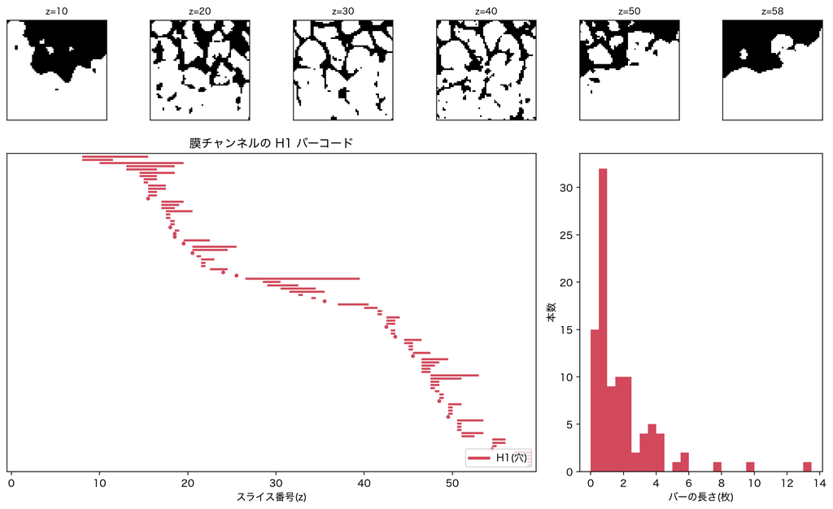

```
H1 バー 97 本。長さの中央値 1 枚、最長 13 枚
```

```python
m = transform.downscale_local_mean(V[:, 0].astype(float), (1, 4, 4))
m = filters.gaussian(m, sigma=(0.5, 0.7, 0.7))
M = np.stack([s > filters.threshold_otsu(s) for s in m])
resM, _ = zigzag(M)
fig = plt.figure(figsize=(12, 7.5))
gs = fig.add_gridspec(2, 6, height_ratios=[1, 2.6])
for j, z in enumerate([10, 20, 30, 40, 50, 58]):
    ax = fig.add_subplot(gs[0, j]); ax.imshow(M[z], cmap="gray_r"); ax.set_title(f"z={z}", fontsize=9)
    ax.set_xticks([]); ax.set_yticks([])
ax = fig.add_subplot(gs[1, :4]); barcode(ax, resM, len(M), dims=(1,), title="膜チャンネルの H1 バーコード")
ax = fig.add_subplot(gs[1, 4:])
L = np.array([(e - a) / 2 for a, e in resM[1]])
ax.hist(L, bins=np.arange(0, L.max() + 1, 0.5), color="#d1495b"); ax.set_xlabel("バーの長さ(枚)"); ax.set_ylabel("本数")
plt.tight_layout(); plt.show()
print(f"H1 バー {len(resM[1])} 本。長さの中央値 {np.median(L):g} 枚、最長 {L.max():g} 枚")
```

細胞1個は 10 枚以上にまたがるはずですが、ほとんどのバーが数枚で切れています。原因は次の2つです。

- 縮小と2値化で膜の線があちこちで途切れ、**輪っかが閉じたり開いたりを繰り返す**。そのたびにバーが切れて、別のバーとして生まれ直す。
- スライスごとに閾値を変えたので、閾値の揺れそのものがバーの切れ目になる。

ジグザグ持続は「2値化したあとの形」を忠実に追うだけです。**2値化が不安定なら、出てくるバーも不安定**です。核の方がうまくいったのは、核がもともと詰まった塊で、2値化に強いからです。

## 6. まとめ:何が言えて、何に気をつけるか

**言えること**

- シリアル画像の「塊・穴がどの深さからどの深さまで続くか」を、対応付けの規則を書かずに一意に要約できる。
- 分岐・合流がバーの誕生・死として出るので、3D ラベリングでは1つに潰れる構造(接した核、枝分かれする管)を分解して見られる。
- 検算(各スライスの連結成分数・オイラー数との一致)で、計算が正しいことを確かめられる。

**気をつけること**

1. **位置合わせ**:和集合で「重なる = 同じもの」とみなしている。スライス間のずれが大きいと偽のバーが出る。
2. **2値化**:閾値1つで結果が変わる(第5節)。閾値も動かすと2パラメータの問題になり、バーコードという形の要約はなくなる。
3. **割り当ては一意でない**:バーの本数と長さは一意だが、「どの塊がどのバーか」は一意でない(第3節の Y 字)。
4. **z が全部そろったボリュームなら、普通の道具でも同じ情報が取れる**:今回の列は、3D 物体の高さ関数の「レベルセット・ジグザグ」と同じもの。これは extended persistence と1対1に対応する(Carlsson–de Silva–Morozov 2009)。ジグザグでしか扱えないのは、**フレーム間に包含がない 3D の時系列**の方です。

## 参考

- G. Carlsson, V. de Silva. *Zigzag Persistence.* Found. Comput. Math. 10 (2010).
- G. Carlsson, V. de Silva, D. Morozov. *Zigzag persistent homology and real-valued functions.* SoCG 2009.
- M. B. Botnan, M. Lesnick. *Algebraic stability of zigzag persistence modules.* AGT 18 (2018).
- T. K. Dey, T. Hou. *Fast Computation of Zigzag Persistence.* ESA 2022.
- D. Morozov. *Dionysus 2*. https://mrzv.org/software/dionysus2/
- scikit-image `skimage.data.cells3d`(Allen Institute for Cell Science の画像に由来)